# 🐍 Practice n°2: exploratory data analysis

## Preparation

### Install & import modules

```python
! pip install seaborn
```

! pip install seaborn

```python
import pandas as pd
import seaborn as sns
import matplotlib.pyplot as plt
```

import pandas as pd import seaborn as sns import matplotlib.pyplot as plt

```python
pd.set_option("display.precision", 2)
sns.set_style("whitegrid")
sns.set_context(rc={"patch.linewidth": 0.15})
```

pd.set_option("display.precision", 2) sns.set_style("whitegrid") sns.set_context(rc={"patch.linewidth": 0.15})

### Read remote dataset

The data is in this git repository: ML-boot-camp/ratebeer.git.

The data is located in the `ratebeer/data/` folder.

```python
file_url = "https://github.com/ML-boot-camp/ratebeer/raw/master/data/ratebeer_sample_enriched.parquet"
```

file_url = "https://github.com/ML-boot-camp/ratebeer/raw/master/data/ratebeer_sample_enriched.parquet"

```python
df = pd.read_parquet(file_url)
```

df = pd.read_parquet(file_url)

## General information

### Shape

Have a first overview of the dataframe size, i.e. number of rows & columns.

Methods you'll need:

- [`pd.DataFrame.shape`](https://pandas.pydata.org/docs/reference/api/pandas.DataFrame.shape.html)

```python
df.shape
```

df.shape

```
(200000, 18)
```

### Overview

Get a few information about the content of the dataframe:

- number of null values per column
- data type of each column
- memory usage

Methods you'll need:

- [`pd.DataFrame.info`](https://pandas.pydata.org/docs/reference/api/pandas.DataFrame.info.html)

```python
df.info(memory_usage="deep")  # LINE TO BE REMOVED FOR STUDENTS
```

df.info(memory_usage="deep") # LINE TO BE REMOVED FOR STUDENTS

```
<class 'pandas.core.frame.DataFrame'>
RangeIndex: 200000 entries, 0 to 199999
Data columns (total 18 columns):
 #   Column             Non-Null Count   Dtype
---  ------             --------------   -----
 0   beer               200000 non-null  object
 1   brewery            200000 non-null  object
 2   alcohol            200000 non-null  float64
 3   type               200000 non-null  object
 4   rating_appearance  200000 non-null  int64
 5   rating_aroma       200000 non-null  int64
 6   rating_palate      200000 non-null  int64
 7   rating_taste       200000 non-null  int64
 8   rating             200000 non-null  int64
 9   timestamp          200000 non-null  object
 10  user               200000 non-null  object
 11  text               200000 non-null  object
 12  beer_degree        200000 non-null  int64
 13  brewery_degree     200000 non-null  int64
 14  user_degree        200000 non-null  int64
 15  text_length        200000 non-null  int64
 16  date               200000 non-null  datetime64[us]
 17  is_good            200000 non-null  int64
dtypes: datetime64[us](1), float64(1), int64(10), object(6)
memory usage: 153.7 MB
```

### Sample

Show a sample of the data

```python
df
```

df

|  | beer | brewery | alcohol | type | rating_appearance | rating_aroma | rating_palate | rating_taste | rating | timestamp | user | text | beer_degree | brewery_degree | user_degree | text_length | date | is_good |
| --- | --- | --- | --- | --- | --- | --- | --- | --- | --- | --- | --- | --- | --- | --- | --- | --- | --- | --- |
| 0 | Breckenridge Oatmeal Stout | 383 | 4.95 | Stout | 4 | 7 | 4 | 7 | 14 | 1217462400 | blutt59 | bottle, oat nose with black color, bitter choc... | 51 | 413 | 300 | 90 | 2008-07-31 02:00:00 | 0 |
| 1 | Breckenridge 471 Small Batch Imperial Porter | 383 | 7.50 | Imperial/Strong Porter | 3 | 8 | 3 | 8 | 14 | 1312588800 | blutt59 | bottle, received in trade, dark brown with gar... | 4 | 413 | 300 | 191 | 2011-08-06 02:00:00 | 0 |
| 2 | Breckenridge Avalanche Amber | 383 | 5.41 | Amber Ale | 3 | 5 | 3 | 5 | 10 | 1205020800 | blutt59 | 12 oz. bottle, amber color with soapy head, sl... | 43 | 413 | 300 | 109 | 2008-03-09 01:00:00 | 0 |
| 3 | Breckenridge Lucky U IPA | 383 | 6.20 | India Pale Ale (IPA) | 3 | 6 | 3 | 7 | 12 | 1255737600 | blutt59 | bottle, golden orange color with light tan foa... | 20 | 413 | 300 | 151 | 2009-10-17 02:00:00 | 0 |
| 4 | Fullers Vintage Ale 2009 | 55 | 8.50 | English Strong Ale | 3 | 7 | 3 | 8 | 14 | 1282003200 | blutt59 | bottle, thanks to SS, almond amber colored pou... | 18 | 978 | 300 | 159 | 2010-08-17 02:00:00 | 0 |
| ... | ... | ... | ... | ... | ... | ... | ... | ... | ... | ... | ... | ... | ... | ... | ... | ... | ... | ... |
| 199995 | Die M Dunkel | 6587 | -1.00 | Dunkel | 4 | 5 | 3 | 3 | 8 | 1204070400 | kuleko | Bottle, supermarket. Very dark colour. Sweet c... | 2 | 2 | 1 | 163 | 2008-02-27 01:00:00 | 0 |
| 199996 | Montt Hafen Porter | 8240 | 6.00 | Porter | 5 | 10 | 5 | 10 | 19 | 1175040000 | Andressantis | Sabrosa,con amargor justo y ligeramente dulce.... | 1 | 1 | 1 | 97 | 2007-03-28 02:00:00 | 1 |
| 199997 | Oxymore | 8022 | 5.00 | Saison | 4 | 8 | 3 | 6 | 12 | 1181952000 | DesmondLangham | Very earthy nose.\tClear and golden, head kept... | 1 | 1 | 1 | 192 | 2007-06-16 02:00:00 | 0 |
| 199998 | Stonehouse Station Bitter | 8561 | 3.90 | Bitter | 3 | 5 | 4 | 6 | 13 | 1238716800 | thedees | Cask at the Three Pigeons Nescliffe. Maly swee... | 1 | 2 | 1 | 88 | 2009-04-03 02:00:00 | 0 |
| 199999 | Pilker Negra | 6687 | 5.00 | Stout | 4 | 6 | 2 | 5 | 5 | 1142553600 | apeters | Roasty aroma.Black color.Dry and bitter flavor... | 1 | 1 | 1 | 144 | 2006-03-17 01:00:00 | 0 |

200000 rows × 18 columns

### Describing statistics

Compute statistics to understand the content of each column.

Methods you'll need:

- [`pd.DataFrame.describe`](https://pandas.pydata.org/docs/reference/api/pandas.DataFrame.describe.html)

Bonus: fill NaN values with an empty string `""` for a better readability using:

- [`pd.DataFrame.fillna`](https://pandas.pydata.org/docs/reference/api/pandas.DataFrame.fillna.html)

```python
df.describe(include="all").fillna("").T
```

df.describe(include="all").fillna("").T

|  | count | unique | top | freq | mean | min | 25% | 50% | 75% | max | std |
| --- | --- | --- | --- | --- | --- | --- | --- | --- | --- | --- | --- |
| beer | 200000 | 42125 | Guinness Draught | 252 |  |  |  |  |  |  |  |
| brewery | 200000 | 5413 | 32 | 3217 |  |  |  |  |  |  |  |
| alcohol | 200000.0 |  |  |  | 6.28 | -1.0 | 5.0 | 5.8 | 8.0 | 57.7 | 2.78 |
| type | 200000 | 89 | India Pale Ale (IPA) | 12698 |  |  |  |  |  |  |  |
| rating_appearance | 200000.0 |  |  |  | 3.43 | 1.0 | 3.0 | 3.0 | 4.0 | 5.0 | 0.81 |
| rating_aroma | 200000.0 |  |  |  | 6.35 | 1.0 | 6.0 | 7.0 | 7.0 | 10.0 | 1.64 |
| rating_palate | 200000.0 |  |  |  | 3.26 | 1.0 | 3.0 | 3.0 | 4.0 | 5.0 | 0.83 |
| rating_taste | 200000.0 |  |  |  | 6.45 | 1.0 | 6.0 | 7.0 | 8.0 | 10.0 | 1.62 |
| rating | 200000.0 |  |  |  | 13.19 | 1.0 | 12.0 | 14.0 | 15.0 | 20.0 | 3.35 |
| timestamp | 200000 | 4105 | 1188604800 | 392 |  |  |  |  |  |  |  |
| user | 200000 | 11251 | fonefan | 1146 |  |  |  |  |  |  |  |
| text | 200000 | 199261 |  | 334 |  |  |  |  |  |  |  |
| beer_degree | 200000.0 |  |  |  | 34.88 | 1.0 | 4.0 | 16.0 | 50.0 | 252.0 | 44.31 |
| brewery_degree | 200000.0 |  |  |  | 605.39 | 1.0 | 68.0 | 304.0 | 828.0 | 3217.0 | 748.4 |
| user_degree | 200000.0 |  |  |  | 156.38 | 1.0 | 34.0 | 97.0 | 204.0 | 1146.0 | 185.3 |
| text_length | 200000.0 |  |  |  | 307.46 | 0.0 | 176.0 | 254.0 | 375.0 | 7989.0 | 212.23 |
| date | 200000 |  |  |  | 2008-03-08 05:48:03.672000 | 2000-04-23 02:00:00 | 2006-05-23 02:00:00 | 2008-07-08 02:00:00 | 2010-05-08 02:00:00 | 2012-01-13 01:00:00 |  |
| is_good | 200000.0 |  |  |  | 0.24 | 0.0 | 0.0 | 0.0 | 0.0 | 1.0 | 0.43 |

## Target

The dataset contains 2 possible targets:

- `rating`: an ordinal variable, which can be used to define a regression
- `is_good`: a binary variable, which can be used to define a classification

In the follow-up of the exploratory data analysis, for the sake of clariy, we'll consider only the binary target (classification). Some plots would be different for numeric target.

### `is_good`

```python
(
    (df.is_good)
    .value_counts()
    .plot.bar()  # LINE TO BE REMOVED FOR STUDENTS
)
```

( (df.is_good) .value_counts() .plot.bar() # LINE TO BE REMOVED FOR STUDENTS )

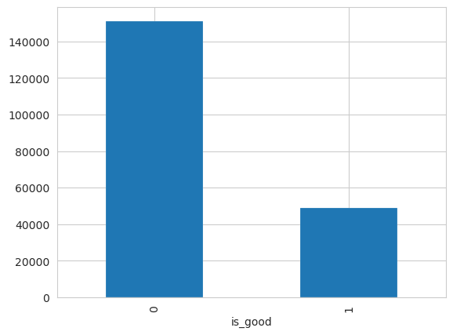

```python
sns.countplot(
    df,
    x="is_good",  # LINE TO BE REMOVED FOR STUDENTS
)
```

sns.countplot( df, x="is_good", # LINE TO BE REMOVED FOR STUDENTS )

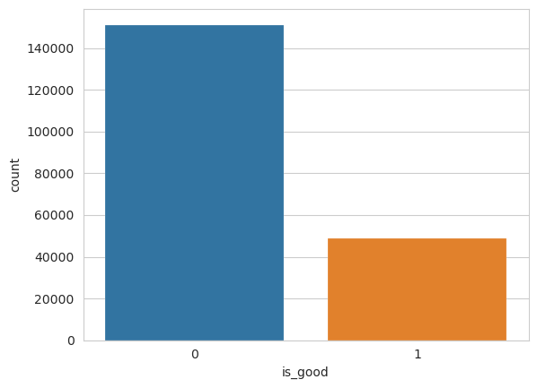

## Quantitative variables

- `alcohol`
- `date`
- `rating_appearance`
- `rating_aroma`
- `rating_palate`
- `rating_taste`

### `alcohol`

#### Distribution

```python
((df.alcohol).plot.hist(bins=100))  # LINE TO BE REMOVED FOR STUDENTS
```

((df.alcohol).plot.hist(bins=100)) # LINE TO BE REMOVED FOR STUDENTS

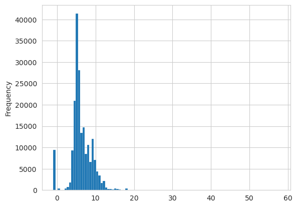

```python
sns.displot(
    df,
    x="alcohol",
)
```

sns.displot( df, x="alcohol", )

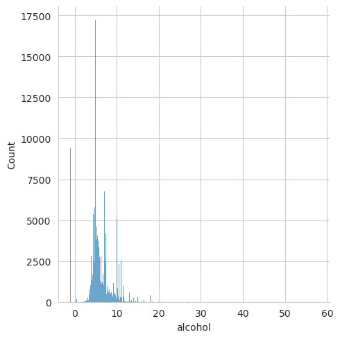

```python
sns.displot(df, x="alcohol", hue="is_good")
```

sns.displot(df, x="alcohol", hue="is_good")

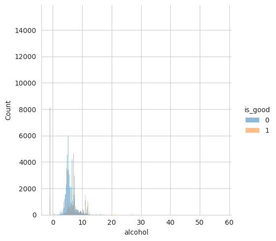

```python
sns.displot(
    df.loc[lambda df: df.alcohol < 20], x="alcohol", hue="is_good"
)
```

sns.displot( df.loc[lambda df: df.alcohol < 20], x="alcohol", hue="is_good" )

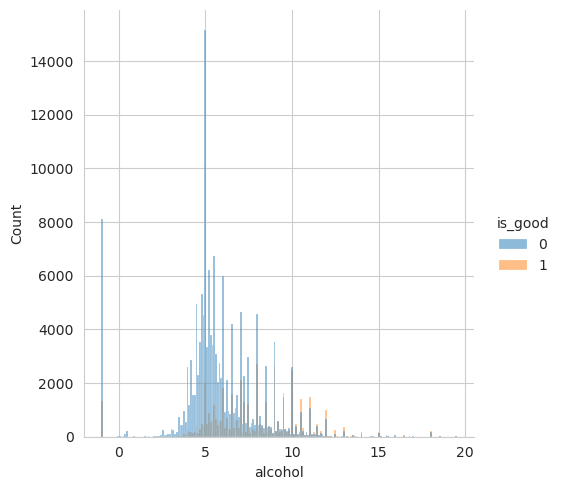

```python
sns.displot(
    df.loc[lambda df: df.alcohol < 20],
    x="alcohol",
    hue="is_good",
    kde=True,
)
```

sns.displot( df.loc[lambda df: df.alcohol < 20], x="alcohol", hue="is_good", kde=True, )

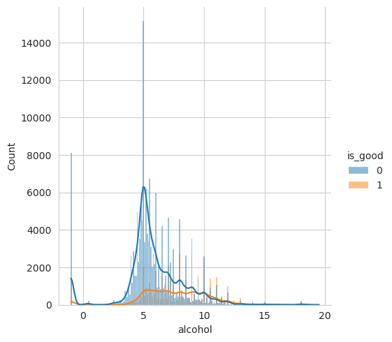

```python
sns.displot(
    df.loc[lambda df: df.alcohol < 20],
    x="alcohol",
    hue="is_good",
    multiple="fill",
)
```

sns.displot( df.loc[lambda df: df.alcohol < 20], x="alcohol", hue="is_good", multiple="fill", )

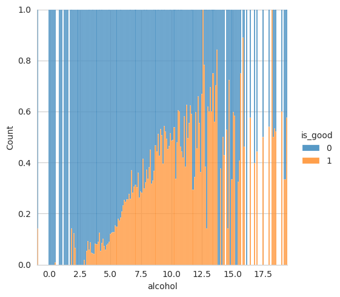

### `date`

#### Distribution

```python
sns.displot(
    df,
    x="date",  # LINE TO BE REMOVED FOR STUDENTS
)
```

sns.displot( df, x="date", # LINE TO BE REMOVED FOR STUDENTS )

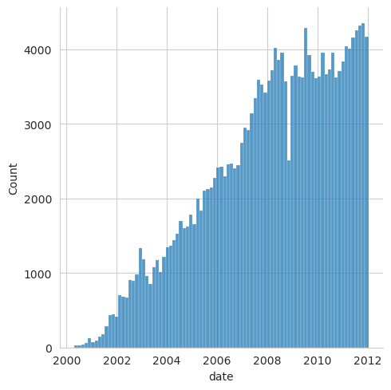

#### Relationship with the target

```python
sns.displot(
    df,
    x="date",  # LINE TO BE REMOVED FOR STUDENTS
    hue="is_good",  # LINE TO BE REMOVED FOR STUDENTS
    kde=True,
)
```

sns.displot( df, x="date", # LINE TO BE REMOVED FOR STUDENTS hue="is_good", # LINE TO BE REMOVED FOR STUDENTS kde=True, )

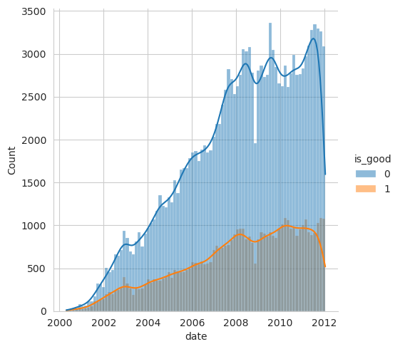

```python
sns.displot(
    df,
    x="date",  # LINE TO BE REMOVED FOR STUDENTS
    hue="is_good",  # LINE TO BE REMOVED FOR STUDENTS
    multiple="fill",
)
```

sns.displot( df, x="date", # LINE TO BE REMOVED FOR STUDENTS hue="is_good", # LINE TO BE REMOVED FOR STUDENTS multiple="fill", )

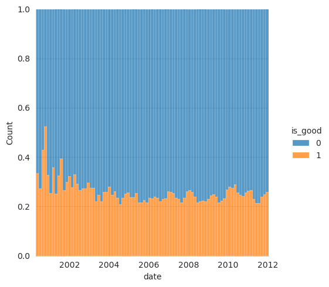

#### Distribution

```python
review_columns = [
    "rating_appearance",
    "rating_aroma",
    "rating_palate",  # LINE TO BE REMOVED FOR STUDENTS
    "rating_taste",  # LINE TO BE REMOVED FOR STUDENTS
]
df_rating_long = df.melt(id_vars="is_good", value_vars=review_columns)
df_rating_long
```

review_columns = [ "rating_appearance", "rating_aroma", "rating_palate", # LINE TO BE REMOVED FOR STUDENTS "rating_taste", # LINE TO BE REMOVED FOR STUDENTS ] df_rating_long = df.melt(id_vars="is_good", value_vars=review_columns) df_rating_long

|  | is_good | variable | value |
| --- | --- | --- | --- |
| 0 | 0 | rating_appearance | 4 |
| 1 | 0 | rating_appearance | 3 |
| 2 | 0 | rating_appearance | 3 |
| 3 | 0 | rating_appearance | 3 |
| 4 | 0 | rating_appearance | 3 |
| ... | ... | ... | ... |
| 799995 | 0 | rating_taste | 3 |
| 799996 | 1 | rating_taste | 10 |
| 799997 | 0 | rating_taste | 6 |
| 799998 | 0 | rating_taste | 6 |
| 799999 | 0 | rating_taste | 5 |

800000 rows × 3 columns

```python
sns.displot(
    df_rating_long,
    x="value",
    row="variable",
    discrete=True,
    height=3,
    aspect=2,
)
```

sns.displot( df_rating_long, x="value", row="variable", discrete=True, height=3, aspect=2, )

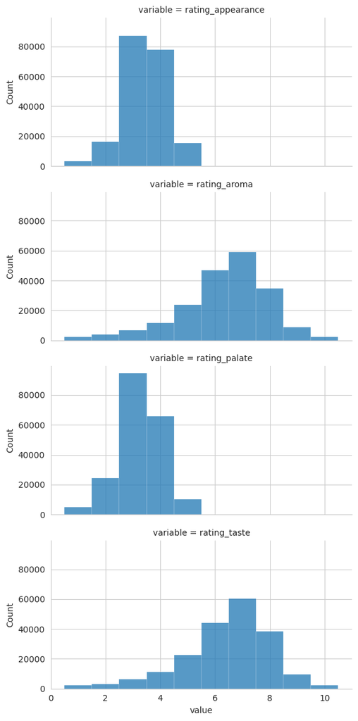

#### Relationship with the target

```python
sns.displot(
    df_rating_long,
    x="value",
    hue="is_good",
    row="variable",
    discrete=True,
    height=3,
    aspect=2,
)
```

sns.displot( df_rating_long, x="value", hue="is_good", row="variable", discrete=True, height=3, aspect=2, )

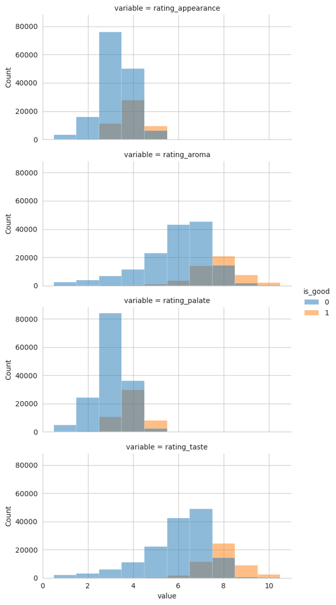

```python
sns.displot(
    df_rating_long,
    x="value",
    hue="is_good",
    row="variable",
    discrete=True,
    height=3,
    aspect=2,
    multiple="fill",
)
```

sns.displot( df_rating_long, x="value", hue="is_good", row="variable", discrete=True, height=3, aspect=2, multiple="fill", )

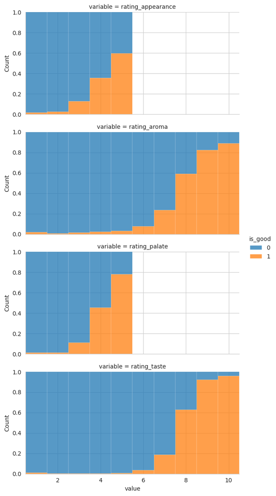

## Categorical variables

- `type`
- `beer`

### `type`

#### Distribution

```python
(
    (df.type)
    .value_counts()
    .plot.bar()
)
```

( (df.type) .value_counts() .plot.bar() )

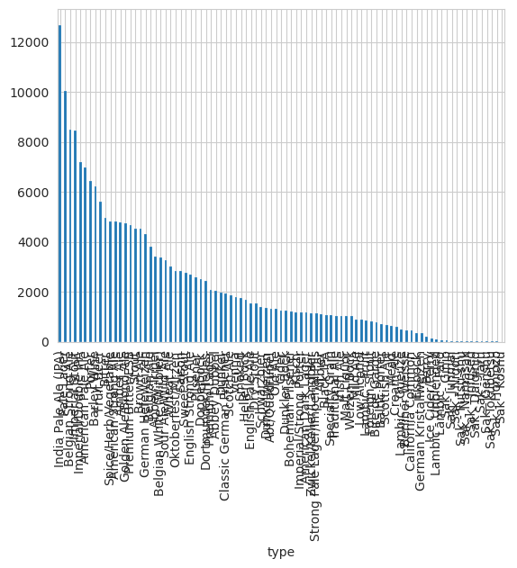

#### Relationship with the target

```python
sns.displot(
    df,
    x="type",
    discrete=True,
    hue="is_good",
)
```

sns.displot( df, x="type", discrete=True, hue="is_good", )

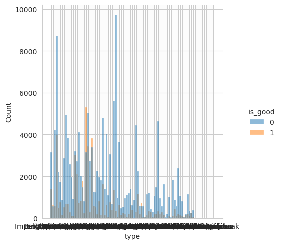

```python
df_styles = (
    (df)
    .groupby("type")
    .is_good.agg(["count", "mean"])
    .add_prefix("review_")
    .reset_index()
    .sort_values(by="review_mean", ascending=False)
    .reset_index(drop=True)
    .assign(
        bar_left_position=lambda df: df.review_count.cumsum().shift(1, fill_value=0)
    )
)
df_styles
```

df_styles = ( (df) .groupby("type") .is_good.agg(["count", "mean"]) .add_prefix("review_") .reset_index() .sort_values(by="review_mean", ascending=False) .reset_index(drop=True) .assign( bar_left_position=lambda df: df.review_count.cumsum().shift(1, fill_value=0) ) ) df_styles

|  | type | review_count | review_mean | bar_left_position |
| --- | --- | --- | --- | --- |
| 0 | Imperial Stout | 8460 | 0.63 | 0 |
| 1 | Ice Cider/Perry | 131 | 0.56 | 8460 |
| 2 | Abt/Quadrupel | 1327 | 0.55 | 8591 |
| 3 | Sour Ale/Wild Ale | 3264 | 0.55 | 9918 |
| 4 | Imperial/Double IPA | 7215 | 0.53 | 13182 |
| ... | ... | ... | ... | ... |
| 84 | Sak - Infused | 16 | 0.00 | 199959 |
| 85 | Sak - Honjozo | 5 | 0.00 | 199975 |
| 86 | Sak - Genshu | 6 | 0.00 | 199980 |
| 87 | Sak - Taru | 9 | 0.00 | 199986 |
| 88 | Sak - Tokubetsu | 5 | 0.00 | 199995 |

89 rows × 4 columns

```python
plt.bar(
    x=df_styles.bar_left_position,
    height=df_styles.review_mean,
    width=df_styles.review_count,
    align="edge",
    alpha=0.5,
    edgecolor="k",
    linewidth=0.5,
)
```

plt.bar( x=df_styles.bar_left_position, height=df_styles.review_mean, width=df_styles.review_count, align="edge", alpha=0.5, edgecolor="k", linewidth=0.5, )

```
<BarContainer object of 89 artists>
```

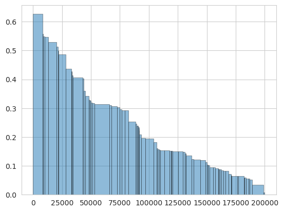

## High cardinality variables

- `beer`
- `brewery`
- `user`

All those high cardinality variables can be thought as links of a network. Indeed, a review is an object comprising a beer, a brewery and a user and can be thought as a network link between them.

In other words, the review table is the a table describing the links in a network with 3 types of nodes: users, beers and breweries.

The first property to compute about each node is its "degree", which is its number of connections with other nodes. High degree means "highly connected".

Analyse the degree of the nodes is a way to answer the following questions:

- is an experienced user more severe ?
- is a new user more forgiving ?
- is a popular beer (or a big brewery) disadvantaged by a "boreness factor" ?
- is a new beer (a small brewery) benefitting from a "novelty factor" ?

To compute the degree you'll need:

- [`pd.Series.value_counts`](https://pandas.pydata.org/docs/reference/api/pandas.Series.value_counts.html)

### `beer` degree

#### Distribution

```python
df_beer_degree = df.loc[:, ["beer", "beer_degree"]].drop_duplicates()
df_beer_degree
```

df_beer_degree = df.loc[:, ["beer", "beer_degree"]].drop_duplicates() df_beer_degree

|  | beer | beer_degree |
| --- | --- | --- |
| 0 | Breckenridge Oatmeal Stout | 51 |
| 1 | Breckenridge 471 Small Batch Imperial Porter | 4 |
| 2 | Breckenridge Avalanche Amber | 43 |
| 3 | Breckenridge Lucky U IPA | 20 |
| 4 | Fullers Vintage Ale 2009 | 18 |
| ... | ... | ... |
| 199994 | Acadie-Broue La Patente | 1 |
| 199996 | Montt Hafen Porter | 1 |
| 199997 | Oxymore | 1 |
| 199998 | Stonehouse Station Bitter | 1 |
| 199999 | Pilker Negra | 1 |

42125 rows × 2 columns

```python
(
    (df_beer_degree.beer_degree)
    .value_counts()
    .reset_index()
    .plot.scatter(
        x="beer_degree", y="count", marker="."  # LINE TO BE REMOVED FOR STUDENTS
    )
)
```

( (df_beer_degree.beer_degree) .value_counts() .reset_index() .plot.scatter( x="beer_degree", y="count", marker="." # LINE TO BE REMOVED FOR STUDENTS ) )

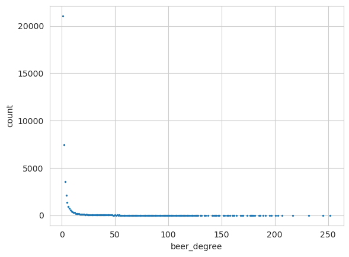

Many networks are [scale free networks](https://en.wikipedia.org/wiki/Scale-free_network):

[figure not shown]

Meaning that the node's degree distribution follows a [power law distribution](https://en.wikipedia.org/wiki/Power_law), which is better visualized using a **log-log scale**:

[figure not shown]

```python
(
    (df_beer_degree.beer_degree)
    .value_counts()
    .reset_index()
    .plot.scatter(  # LINE TO BE REMOVED FOR STUDENTS
        x="beer_degree",  # LINE TO BE REMOVED FOR STUDENTS
        y="count",  # LINE TO BE REMOVED FOR STUDENTS
        loglog=True,  # LINE TO BE REMOVED FOR STUDENTS
        marker="."  # LINE TO BE REMOVED FOR STUDENTS
    )  # LINE TO BE REMOVED FOR STUDENTS
)
```

( (df_beer_degree.beer_degree) .value_counts() .reset_index() .plot.scatter( # LINE TO BE REMOVED FOR STUDENTS x="beer_degree", # LINE TO BE REMOVED FOR STUDENTS y="count", # LINE TO BE REMOVED FOR STUDENTS loglog=True, # LINE TO BE REMOVED FOR STUDENTS marker="." # LINE TO BE REMOVED FOR STUDENTS ) # LINE TO BE REMOVED FOR STUDENTS )

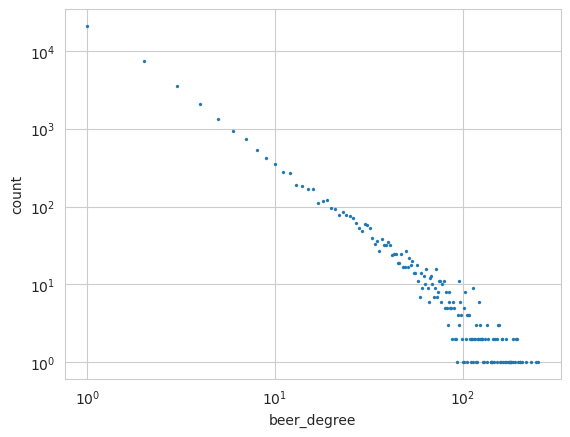

Another way to visualize the power law distribution is to visualize the [rank-frequency plot](https://en.wikipedia.org/wiki/Rank%E2%80%93size_distribution).

Instead of plotting the frequency as a function of the value (like in a normal distribution plot), we plot the frequency as a function of its rank. Note: It's always monotonically decreasing.

Power law distributions exhibit also a distinctive visual pattern in the rank-frequency plot, known as the Zipf's law:

[figure not shown]

```python
def plot_rank_size(series):
    return (
        (series)
        .rename("")
        .value_counts()
        .reset_index()
        .assign(rank=lambda df: range(1, 1 + df.shape[0]))
        .plot(x="rank", y="count", loglog=True, marker=".")
    )
```

def plot_rank_size(series): return ( (series) .rename("") .value_counts() .reset_index() .assign(rank=lambda df: range(1, 1 + df.shape[0])) .plot(x="rank", y="count", loglog=True, marker=".") )

```python
plot_rank_size(df_beer_degree.beer_degree)
```

plot_rank_size(df_beer_degree.beer_degree)

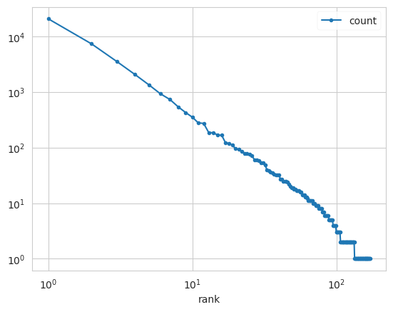

#### Relationship with target

```python
sns.displot(df, x="beer_degree", hue="is_good")
```

sns.displot(df, x="beer_degree", hue="is_good")

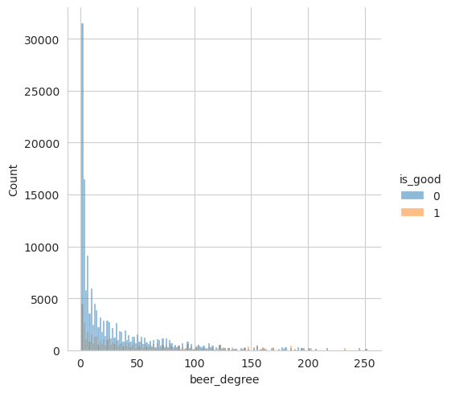

```python
sns.displot(df, x="beer_degree", hue="is_good", log_scale=True)
```

sns.displot(df, x="beer_degree", hue="is_good", log_scale=True)

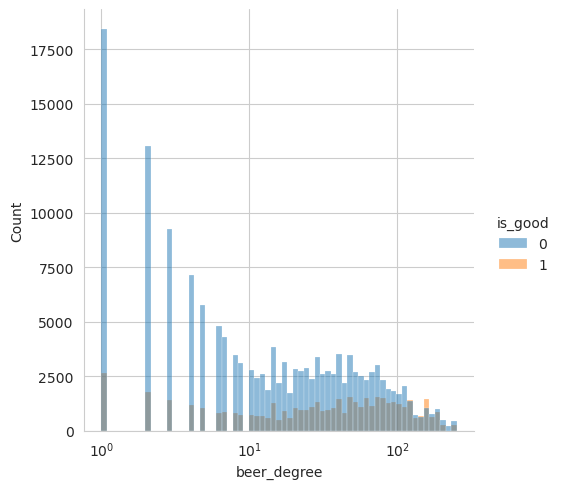

```python
sns.displot(
    df,
    x="beer_degree",
    hue="is_good",
    log_scale=True,
    multiple="fill",
)
```

sns.displot( df, x="beer_degree", hue="is_good", log_scale=True, multiple="fill", )

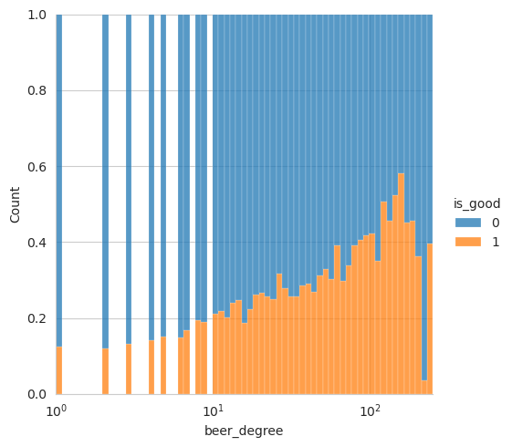

### `brewery`

#### Distribution

```python
df_brewery_degree = df.loc[:, ["brewery", "brewery_degree"]].drop_duplicates()
df_brewery_degree
```

df_brewery_degree = df.loc[:, ["brewery", "brewery_degree"]].drop_duplicates() df_brewery_degree

|  | brewery | brewery_degree |
| --- | --- | --- |
| 0 | 383 | 413 |
| 4 | 55 | 978 |
| 5 | 32 | 3217 |
| 9 | 284 | 610 |
| 10 | 149 | 400 |
| ... | ... | ... |
| 199992 | 13436 | 2 |
| 199994 | 12747 | 1 |
| 199996 | 8240 | 1 |
| 199997 | 8022 | 1 |
| 199999 | 6687 | 1 |

5413 rows × 2 columns

```python
(
    (df_brewery_degree.brewery_degree)
    .value_counts()
    .reset_index()
    .plot.scatter(  # LINE TO BE REMOVED FOR STUDENTS
        x="brewery_degree",  # LINE TO BE REMOVED FOR STUDENTS
        y="count",  # LINE TO BE REMOVED FOR STUDENTS
        marker=".",  # LINE TO BE REMOVED FOR STUDENTS
    )  # LINE TO BE REMOVED FOR STUDENTS
)
```

( (df_brewery_degree.brewery_degree) .value_counts() .reset_index() .plot.scatter( # LINE TO BE REMOVED FOR STUDENTS x="brewery_degree", # LINE TO BE REMOVED FOR STUDENTS y="count", # LINE TO BE REMOVED FOR STUDENTS marker=".", # LINE TO BE REMOVED FOR STUDENTS ) # LINE TO BE REMOVED FOR STUDENTS )

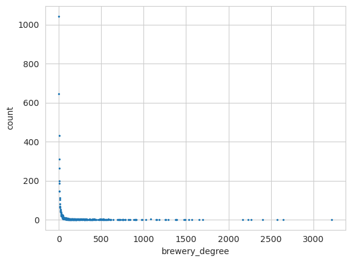

```python
(
    (df_brewery_degree.brewery_degree)
    .value_counts()
    .reset_index()
    .plot.scatter(  # LINE TO BE REMOVED FOR STUDENTS
        x="brewery_degree",  # LINE TO BE REMOVED FOR STUDENTS
        y="count",  # LINE TO BE REMOVED FOR STUDENTS
        loglog=True,  # LINE TO BE REMOVED FOR STUDENTS
        marker=".",  # LINE TO BE REMOVED FOR STUDENTS
    )  # LINE TO BE REMOVED FOR STUDENTS
)
```

( (df_brewery_degree.brewery_degree) .value_counts() .reset_index() .plot.scatter( # LINE TO BE REMOVED FOR STUDENTS x="brewery_degree", # LINE TO BE REMOVED FOR STUDENTS y="count", # LINE TO BE REMOVED FOR STUDENTS loglog=True, # LINE TO BE REMOVED FOR STUDENTS marker=".", # LINE TO BE REMOVED FOR STUDENTS ) # LINE TO BE REMOVED FOR STUDENTS )

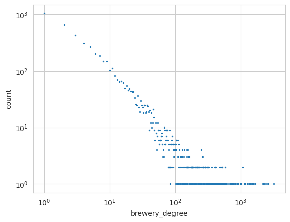

```python
plot_rank_size(df_brewery_degree.brewery_degree)
```

plot_rank_size(df_brewery_degree.brewery_degree)

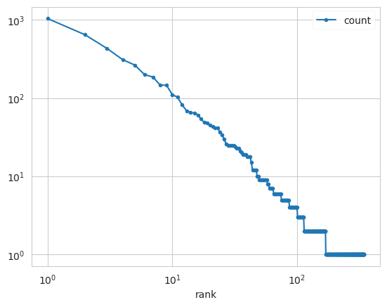

#### Relationship with target

```python
sns.displot(df, x="brewery_degree", hue="is_good")
```

sns.displot(df, x="brewery_degree", hue="is_good")

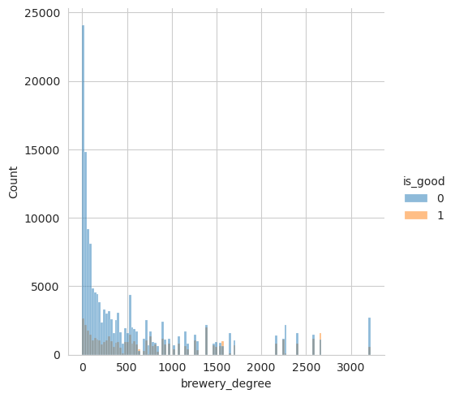

```python
sns.displot(
    df, x="brewery_degree", hue="is_good", log_scale=True
)
```

sns.displot( df, x="brewery_degree", hue="is_good", log_scale=True )

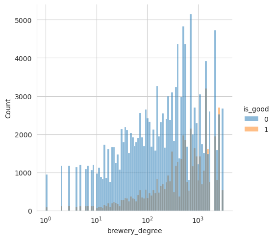

```python
sns.displot(
    df,
    x="brewery_degree",
    hue="is_good",
    log_scale=True,
    multiple="fill",
)
```

sns.displot( df, x="brewery_degree", hue="is_good", log_scale=True, multiple="fill", )

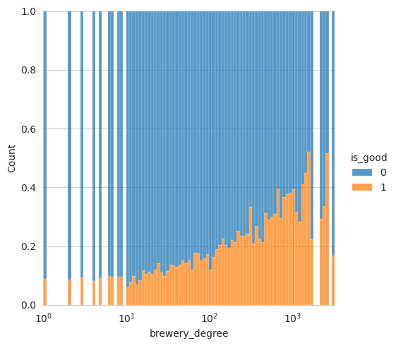